# Data Science Capstone Milestone Report

Alia Amin

Sunday, July 19, 2015

## Synopsis

In this report, we summarize the preliminary results of the capstone project. This report explains 1) where the dataset is obtained; 2) how the data is cleaned and processed, 3) basic summary statistics of the datasets and findings and 4) future work.

## Data Processing

### Step 1: Download Dataset

The data used in this project is from a corpus called HC Corpora . See the readme file at http://www.corpora.heliohost.org/aboutcorpus.html for details on the corpora available. The files have been language filtered but may still contain some foreign text. The datasets is available in 4 different languages: English, German, Russian and Finish. For each language, there are 3 types of sources available: twitter dataset, Blog dataset and news dataset. The dataset can be downloaded from: https://d396qusza40orc.cloudfront.net/dsscapstone/dataset/Coursera-SwiftKey.zip. **Throughout this project, we will use the English language dataset only.**

### Step 2. Dataset clean up

To make processing these very large datasets easier, we broke the clean up process into 7 parts: blog, news, and 5 twitter files. We cleaned up the dataset for each sources (twitter (5 parts), blog, news) separately, with the intention of merging them together only after the datasets are processed. The cleaned up each dataset is an iterative process using the TM library in the following order:

- convert all characters to lower character
- convert shortened words (apostroph’s words) to original words (reference: http://www.textfixer.com/resources/common-english-words.php)
- remove the remaining apostroph characters
- remove punctuations
- remove numbers
- remove urls
- remove non alphanumeric characters
- remove whitespaces

After the clean up process above, the all cleaned dataset is stored in RDS format. Due to the extensiveness of these operation the cleanup process is done separately from this report. For more detail on the codes used in the dataset clean up preprocessing, please refer to http://github.com/aliaamin/sw.

### 2.2. Step 3. Dataset Summary

```r
#load step 1. original dataset
tfilename <- "./Coursera-SwiftKey/final/en_US/en_US.twitter.txt"
nfilename <- "./Coursera-SwiftKey/final/en_US/en_US.news.txt"
bfilename <- "./Coursera-SwiftKey/final/en_US/en_US.blogs.txt"

# load step 2. cleanned dataset
t1rdsfilename <- "./MilestoneReport/data/en_US.cleaned_twitter1.RDS"
t2rdsfilename <- "./MilestoneReport/data/en_US.cleaned_twitter2.RDS"
t3rdsfilename <- "./MilestoneReport/data/en_US.cleaned_twitter3.RDS"
t4rdsfilename <- "./MilestoneReport/data/en_US.cleaned_twitter4.RDS"
t5rdsfilename <- "./MilestoneReport/data/en_US.cleaned_twitter5.RDS"
blogrdsfilename <- "./MilestoneReport/data/en_US.cleaned_blog.RDS"
newsrdsfilename <- "./MilestoneReport/data/en_US.cleaned_news.RDS"
```

```r
# Summary of original datasets, step 1 load dataset
print(originaldataset)
```

```
##      filename            file size   #lines    #words
## [1,] "en_US.twitter.txt" "167105338" "2360148" "30341028"
## [2,] "en_US.blogs.txt"   "210160014" "899288"  "37272578"
## [3,] "en_US.news.txt"    "205811889" "77259"   "34309642"
```

```r
# After step 2. dataset clean up
print(cleanneddataset)
```

```
##      filename                     file size
## [1,] "en_US.cleaned_twitter1.RDS" "27370902"
## [2,] "en_US.cleaned_twitter2.RDS" "27155466"
## [3,] "en_US.cleaned_twitter3.RDS" "26976740"
## [4,] "en_US.cleaned_twitter4.RDS" "27314543"
## [5,] "en_US.cleaned_twitter5.RDS" "2175956"
## [6,] "en_US.cleaned_blog.RDS"     "104636459"
## [7,] "en_US.cleaned_news.RDS"     "8187458"
```

### Step 4. Exploratory Analysis

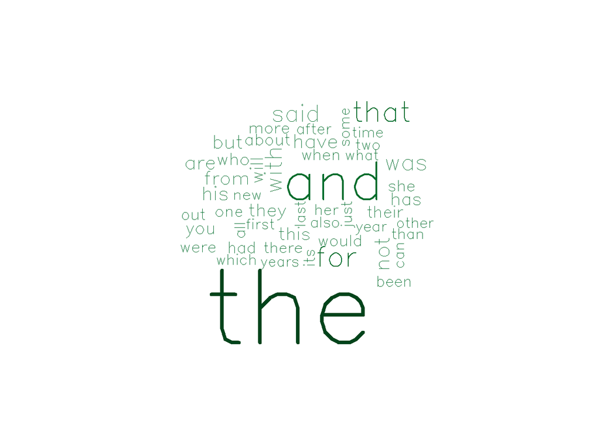

```r
UnigramTokenizer <- function(x) NGramTokenizer(x, Weka_control(min = 1, max = 1))

files <- c(t1rdsfilename, t2rdsfilename, t3rdsfilename, t4rdsfilename, t5rdsfilename, blogrdsfilename, newsrdsfilename)

tdm_total <- 0

for (i in 1:length(files)) {

cleanedCorpus <- readRDS(files[i])
tdm_a <- TermDocumentMatrix(cleanedCorpus, control = list(tokenize = UnigramTokenizer))
cleanedCorpus <- 0
tdm_total <- c(tdm_a)
tdm_a <- 0

}

# counting the frequency of each word
tdm1 <- rollup(tdm_total, 2, na.rm=TRUE, FUN = sum)
frequency <- slam::row_sums(tdm1, na.rm = T)
frequency <- sort(frequency, decreasing=TRUE)
words <- names(frequency)

pal <- brewer.pal(9, "BuGn")
pal <- pal[-(1:7)]
wordcloud(words[1:50], frequency[1:50], scale=c(8,.9), random.order=T, rot.per=.15, colors=pal, vfont=c("sans serif","plain"))
```

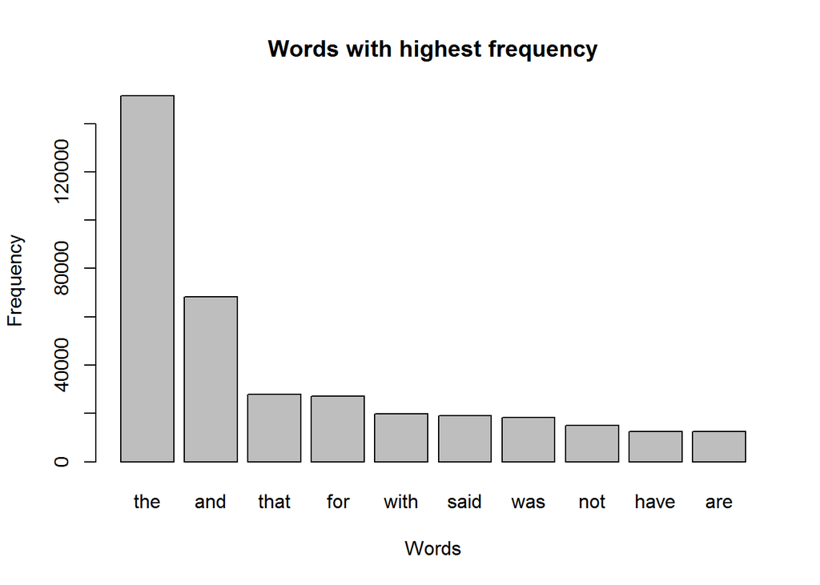

```r
barplot(frequency[1:10], main = "Words with highest frequency", xlab = "Words", ylab = "Frequency")
```

```r
#A list of 50 most frequent words
print(rbind(frequency[1:50]))
```

```
##         the   and  that   for  with  said   was   not  have   are   his
## [1,] 151524 68216 27972 27112 19754 19167 18232 15069 12552 12401 12107
##        but  from will they  has this  you  who about were more their would
## [1,] 11658 11648 9886 9827 9550 9448 8635 8375  6932 6782 6729  6705  6420
##       one  had  she when  out  her  new there  its been  all after which
## [1,] 6414 6272 6195 5931 5555 5364 5337  5227 5173 5162 5116  4728  4620
##      also than year  two  can what first just last time some years other
## [1,] 4515 4489 4470 4438 4403 4291  4150 4144 4027 3992 3988  3987  3930
```

### Step 5. Future work

There are 2 further steps that we will do to improve the model:

1. The next step for this research is to reduce the size of the model without compromising quality. One way to achieve this is to remove the longtail words that in total occur only once. This word is most likely a typo. Through manual examination of the cleanned data, we found this case occurs a lot in blog and twitter datasets where the language and typing style are more loose.
2. work on the 2-gram and 3-gram model that will be use for prediction.